# STA 404 Project 1: Ohio COVID Dashboard

Author: Ben Maldonado  
Date updated: 4/7/21

References:  
*all of the following references are links to code with brief analysis on why they were used*  
1. http://www.sthda.com/english/wiki/ggplot2-title-main-axis-and-legend-titles - *helped with centering titles*  
2. https://stackoverflow.com/questions/35090883/remove-all-of-x-axis-labels-in-ggplot - *helped with creating proper themes*  
3. https://felixfan.github.io/ggplot2-remove-grid-background-margin/ - *helped with creating proper themes*  
4. http://www.sthda.com/english/wiki/ggplot2-themes-and-background-colors-the-3-elements - *helped with creating proper themes*  
5. https://stackoverflow.com/questions/40675778/center-plot-title-in-ggplot2 - *helped with centering titles*  
6. https://emanuelaf.github.io/own-ggplot-theme.html - *helped with creating themes*  
7. https://stackoverflow.com/questions/22945651/how-to-remove-space-between-axis-area-plot-in-ggplot2 - *helped with recreating spacing*  
8. https://stackoverflow.com/questions/31568453/using-different-font-styles-in-annotate-ggplot2 - *helped with changing to bold font*  
9. # https://www.geeksforgeeks.org/convert-first-letter-of-every-word-to-uppercase-in-r-programming-str_to_title-function/#:~:text=str_to_title()%20Function%20in%20R,are%20converted%20to%20lower%20case. - *helped with inner joins on the map dataset*  
10. https://www.r-bloggers.com/2018/08/how-to-cite-packages/ - *citation help*  
11. https://patchwork.data-imaginist.com/articles/guides/annotation.html - *help with patchwork*  
12. https://r-graphics.org/recipe-bar-graph-adjust-width - *helped with bar thickness on bar charts*  
13. https://stackoverflow.com/questions/29465941/format-number-in-r-with-both-comma-thousands-separator-and-specified-decimals - *helped with formatting numbers with commas*  
14. https://ggplot2.tidyverse.org/reference/geom_text.html - *helped with properly placing the geom_text values*  
Citations:  
*Dataset aggregation and graphic creation was done using R 4.0.4 (R Core Team, 2021) and the tidyverse (v1.3.0; Wickham et al., (2019), patchwork (v1.1.1; Pederson (2020)), ggmap (v3.0.0; D. Kahle and H. Wickham. (2019)) packages. Some more minor packages included lubridate, mapproj, stringr, and formattable. Full code is down below.*  
Datesets:  
1. OhioDF - the Ohio COVID-19 Dataset (https://coronavirus.ohio.gov/static/dashboards/COVIDDeathData_CountyOfResidence.csv)  
2. OhioDF_clean - removed unnecessary columns from the raw data  
3. OhioDF_cases_agg - aggregates all case counts for each day  
4. OhioDF_hosp_agg - aggregates all hospitalizations counts for each day  
5. OhioDF_deaths_agg - aggregates all death counts for each day  
6. OhioDF_agg - combines all of the aggregate datasets  
7. OhioDF_county_cases - aggregates of case counts on the county level  
8. OhioDF_county_hosp - aggregates of hospitalization counts on the county level  
9. OhioDF_county_deaths - aggregates of deaths counts on the county level  
10. OhioDF_county - combines all county-level data together  
11. OhioDF_top20 - only selects the top 20 case count-counties  
12. County_map - a map of all US counties  
13. Ohio_map - isolates the county maps down to just Ohio  
14. Ohio_map_clean - prepares the county dataset for merging  
15. OhioDF_map - joins the aggregate counts by county level to the map data

```r
library(tidyverse) # used for dataset operations
library(patchwork) # used for creating final dashboard
library(lubridate) # used for proper date objects
library(ggmap) # used for creating the ohio map
library(mapproj) # used for creating the ohio map
library(stringr) # used for joining the ohio map data with case data
library(formattable) # used for printing numbers with commas
```

## Load the dataset and format it correctly

```r
# this block focuses on loading in the initial dataset

# load in the dataset and change their column names and types to be more readable
OhioDF <- read_csv(
  file="https://coronavirus.ohio.gov/static/dashboards/COVIDDeathData_CountyOfResidence.csv",
  col_names = c("County","Sex","AgeRange","cOnsetDate","cHospDate",
                "cDeathDate","CaseCount","HospCount",
                "DeathCount"), # fix names of the columns
  col_types = "cccccciii", # fix the datatypes
  skip=1) # skip the title line


# check out the dataset
# view(OhioDF)
# names(OhioDF)


# gets rid of the AgeRange and Sex variables
OhioDF_clean <- OhioDF %>%
  filter(County != "Unknown") %>% # get rid of the random unknown county
  # SOLUTION PULLED FROM DR. BAILER
   mutate(OnsetDate = ymd(cOnsetDate),
         HospDate = ymd(cHospDate),
         DeathDate = ymd(cDeathDate)) %>% # correct the format of the improper variables
  select(County, OnsetDate, HospDate, DeathDate, CaseCount, HospCount, DeathCount)
```

```
Problem with `mutate()` input `HospDate`.
x  5615 failed to parse.
i Input `HospDate` is `ymd(cHospDate)`. 5615 failed to parse.
```

```r
# check out the dataset
# view(OhioDF_clean)
# str(OhioDF_clean)

# FOR NOTES:
# onset date -> cases; admission date -> hospitalized count
# date of death -> death count
```

## Aggregate Time-Series plots

```r
# this block is meant to build the datasets for the aggregate time series charts

# cases dataset
OhioDF_cases_agg <- OhioDF_clean %>%
  mutate(Date = OnsetDate) %>% # give something for the innerjoin
  group_by(Date) %>%
  summarize(Cases=sum(CaseCount)) # aggregate the case counts
# hosp dataset
firstCase <- min(OhioDF_clean$OnsetDate, na.rm=TRUE) # define the first case to fix some of the broken dates

OhioDF_hosp_agg <- OhioDF_clean %>%
  mutate(Date=HospDate) %>% # give something for inner join
  group_by(Date) %>%
  summarize(Hosps=sum(HospCount)) %>% # aggregate the hosp counts
  filter(Date>=firstCase)
# death dataset
OhioDF_deaths_agg <- OhioDF_clean %>%
  mutate(Date = DeathDate) %>% # give something for the inner join
  group_by(Date) %>%
  summarize(Deaths=sum(DeathCount)) # aggregate the deaths count
# aggregate dataset of all of the above datasets
OhioDF_agg <- OhioDF_cases_agg %>%
  inner_join(OhioDF_hosp_agg) %>%
  inner_join(OhioDF_deaths_agg) %>%
  filter(!is.na(Date)) #get rid of empty dates
# verify the dataset is right
# view(OhioDF_agg)

# maximum counts
total_cases = as.numeric(max(cumsum(OhioDF_agg$Cases))) # collect highest counts; these have to be coerced into a value
total_hosp = as.numeric(max(cumsum(OhioDF_agg$Hosps)))
total_deaths = as.numeric(max(cumsum(OhioDF_agg$Deaths)))
```

```r
# this block is meant to create a cohesive theme for the timeseries plots
theme_covid_ohio_agg <- function() {
  theme(axis.text.x=element_text(color="black", size=10), # correct x text to be the correct size
        axis.title.x=element_blank(), # get rid of x label
        axis.text.y=element_blank(), # get rid of y texts
        axis.title.y=element_blank(), # get rid of y label
        axis.ticks.y=element_blank(), # get rid of y ticks
        panel.grid.major = element_blank(),  # get rid of the grid lines
        panel.grid.minor = element_blank(), # get rid of the grid lines
        panel.background=element_rect(fill = "#dce8f2") # color the background
  )
}
```

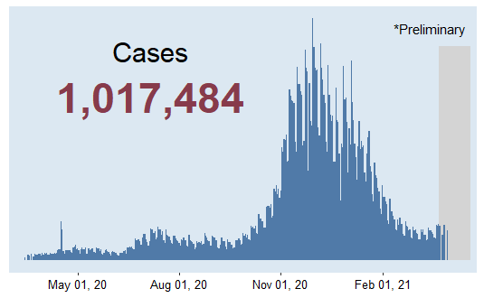

```r
# this block is meant to create the various plots for the timeseries data

# cases plot
cases_agg <- ggplot(OhioDF_agg, aes(x=Date, y=Cases))+
  geom_rect(xmin=today()-14, xmax=today()+15, ymin=0, ymax=11750, fill="#d4d4d4")+ # grey bar for "preliminary cases"
  annotate(geom="text",x=today()-55, y=12750,label="*Preliminary", size=4, hjust=0) + # label for "preliminary cases"
  annotate(geom="text",x=today()-275, y=11500,label="Cases", size=8) + # marks the label for this graph (cases)
  annotate(geom="text",x=today()-275, y=9000,label=comma(total_cases, digits=0), size=12, color="#873b4b", fontface=2) + # marks the total number of cases in ohio; the comma() function places the value on the graphic with commas at the proper notation points (digits=0 means that we won't have any decimal points)
  scale_x_date(limits=c(as.Date("2020-03-01"),today()+20), date_breaks = "3 months", date_labels="%b %d, %y", expand = c(0,.75))+ # sets the proper scaling on the bottom of the graphic to match the covid dashboard
  geom_col(fill="#507aa8", width=1)+ # cases timeseries; fix the width of the bars so there aren't weird gaps
  theme_covid_ohio_agg() # proper theme


# hospitalizations plot
hosp_agg <- ggplot(OhioDF_agg, aes(x=Date, y=Hosps))+
  geom_rect(xmin=today()-14, xmax=today()+15, ymin=0, ymax=360, fill="#d4d4d4")+ # grey bar for "preliminary cases"
  annotate(geom="text",x=today()-55, y=387,label="*Preliminary", size=4, hjust=0) + # label for "preliminary cases"
  annotate(geom="text",x=today()-275, y=360,label="Hospitalizations", size=8) + # marks the label for this graph (hospitalizations)
  annotate(geom="text",x=today()-275, y=285,label=comma(total_hosp, digits=0), size=12, color="#873b4b", fontface=2) + # marks the total number of hospitalizations in ohio
  scale_x_date(limits=c(as.Date("2020-03-01"), today()+20), date_breaks = "3 months", date_labels="%b %d, %y", expand = c(0,.75))+ # sets the proper scaling on the bottom of the graphic to match the covid dashboard
  geom_col(fill="#507aa8", width=1)+ # hospitalizations timeseries
  theme_covid_ohio_agg() # proper theme


# deaths plot
deaths_agg <- ggplot(OhioDF_agg, aes(x=Date, y=Deaths))+
  geom_rect(xmin=today()-14, xmax=today()+15, ymin=0, ymax=185, fill="#d4d4d4")+ # grey bar for "preliminary cases"
  annotate(geom="text",x=today()-55, y=200,label="*Preliminary", size=4, hjust=0) + # label for "preliminary cases"
  annotate(geom="text",x=today()-275, y=180,label="Deaths", size=8) + # marks the label for this graph (deaths)
  annotate(geom="text",x=today()-275, y=143,label=comma(total_deaths, digits=0), size=12, color="#873b4b", fontface=2) + # aggregate death count in ohio
  scale_x_date(limits=c(as.Date("2020-03-01"),today()+20), date_breaks = "3 months", date_labels="%b %d, %y",expand = c(0,.75))+ # sets the proper scaling on the bottom of the graphic to match the covid dashboard
  geom_col(fill="#507aa8", width=1)+ # deaths timeseries
  theme_covid_ohio_agg() # proper theme


# show these off for the notebook
cases_agg
```

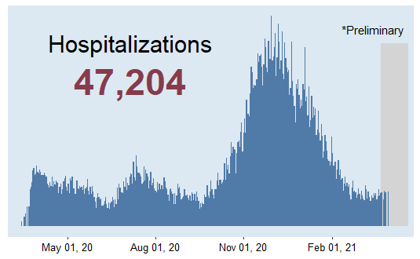

```r
hosp_agg
```

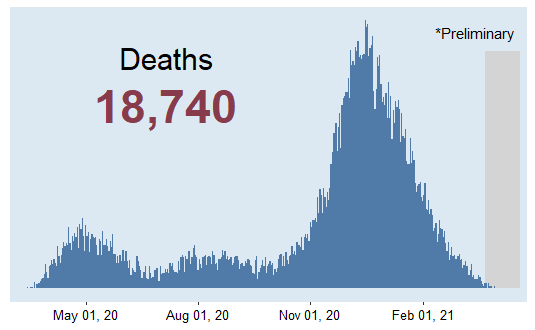

```r
deaths_agg
```

## County-level Plots

```r
# this block is meant to create the datasets for the county level counts of cases, hospitalizations, and deaths

# cases dataset
OhioDF_county_cases <- OhioDF_clean %>%
  filter(!is.na(OnsetDate)) %>% # remove na onset dates
  group_by(County, OnsetDate) %>% # group by the County and dates
  summarize(Cases=sum(CaseCount)) %>% # count up the cases for each date
  mutate(TotalCases=cumsum(Cases)) %>% # total up all of the cases for this county on a particular day
  filter(OnsetDate == max(OnsetDate)) %>% # select only the newest day
  select(-c(OnsetDate, Cases)) # drop the unnecessary columns
# hosps dataset
OhioDF_county_hosp <- OhioDF_clean %>%
  filter(!is.na(HospDate)) %>% # remove na hosp dates
  group_by(County, HospDate) %>% # group by the County and dates
  summarize(Hosps=sum(HospCount)) %>% # count up the cases for each date
  mutate(TotalHosp=cumsum(Hosps)) %>% # total up all of the cases for this county on a particular day
  filter(HospDate == max(HospDate)) %>% # select only the newest day
  select(-c(HospDate, Hosps)) # drop the unnecessary columns
# death dataset
OhioDF_county_deaths <- OhioDF_clean %>%
  filter(!is.na(DeathDate)) %>% # remove na onset dates
  group_by(County, DeathDate) %>% # group by the County and dates
  summarize(Deaths=sum(DeathCount)) %>% # count up the cases for each date
  mutate(TotalDeaths=cumsum(Deaths)) %>% # total up all of the cases for this county on a particular day
  filter(DeathDate == max(DeathDate)) %>% # select only the newest day
  select(-c(DeathDate, Deaths)) # drop the unnecessary datapoints
# proper order on cases
oo <- order(OhioDF_county_cases$TotalCases, decreasing=TRUE) # orders the cases in decreasing order from most to least
top20 <- as.vector(OhioDF_county_cases$County[oo])[1:20] # choose the top 20 counties


# aggregate dataset
OhioDF_county <-OhioDF_county_cases %>%
  inner_join(OhioDF_county_deaths) %>%
  inner_join(OhioDF_county_hosp) %>%
  mutate(CaseCat = cut(TotalCases, breaks = c(0, 1000, 2500, 5000,
                                  15000, 30000, 50000,
                                  100000, 1000000)),
         # the CaseCat is for both the bar graphs and the map, so it has more categories
         HospCat = cut(TotalHosp, breaks = c(0, 500, 750, 1500,
                                             3000, 5000, 10000)),
         # JUST for the bar graphs
         DeathCat = cut(TotalDeaths, breaks= c(0, 50, 100, 250,
                                               500, 750, 1000,
                                               2000, 3000)))
        # JUST for the bar graphs
# create the category that breaks the counts of cases into various categories for coloring

# get rid of the 20 counties we don't need
OhioDF_top20 <- OhioDF_county %>%
  filter(County %in% top20)
```

```r
# this block of code creates color maps for the bar graphs and map

# selects colors that are dark blue to grey
colors = c("#2a5783", "#507aa8", "#6c96bc", "#74a5cc", "#96c4e2",
                 "#b0d2e3", "#bed4dd", "#cbd6d7") # these will need to be manually listed in the bar graphs for proper coloring to occur
bar_colors = c("#b0d2e3", "#96c4e2", "#74a5cc",
               "#6c96bc", "#507aa8", "#2a5783")
map_colors = rev(colors) # map goes other direction for whatever reason
```

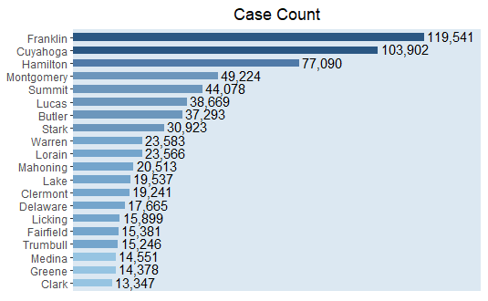

```r
# this block of code is meant to create the bar graphs of the county level data

# case plot
cases_bar <- ggplot(OhioDF_top20, aes(x=TotalCases, y=fct_reorder(County,TotalCases), fill=CaseCat)) + # orders the y axis based on the highest number of cases
  geom_col(width=.6) + # plot the county data
  geom_text(aes(label=comma(TotalCases, digits=0), hjust=0),
            nudge_y=.1, nudge_x=1000) + # label the county data; put proper commas in the labels; the slight nudge means they align properly with the bars
  labs(title="Case Count")+ # add a title
  guides(fill="none")+ # get rid of the legend
  scale_fill_manual(values=bar_colors[2:6]) + # puts in the color schemes we looked at before; we only want the last 5 colors
  scale_x_continuous(expand=c(0,0), limits=c(0,139000)) + # makes sure that gaps at ends of graphic are good by getting rid of padding and setting the right limit to be far enough to read the text properly
  theme(
        axis.text.x = element_blank(), # get rid of the x text
        axis.title.x = element_blank(), # get rid of the x axis label
        axis.ticks.x = element_blank(), # get rid of the x ticks
        axis.title.y=element_blank(), # get rid y axis label
        panel.grid.major = element_blank(), # gets rid of grid lines
        panel.grid.minor = element_blank(),
        panel.background=element_rect(fill = "#dce8f2"), # proper background color
        plot.title = element_text(hjust=.5) # center the title
  )

# hosp
hosp_bar <- ggplot(OhioDF_top20, aes(x=TotalHosp, y=fct_reorder(County,TotalCases), fill=HospCat)) +
  # orders the y axis based on the highest number of cases (even though this is not the cases bar graph)
  geom_col(width=.6)+ # plot the county data
  geom_text(aes(label=comma(TotalHosp, digits=0), hjust=0),
            nudge_y=.1, nudge_x=50) + # label the county data
  labs(title="Hospitalization Count")+ # add a title
  guides(fill="none")+ # get rid of the legend
  scale_fill_manual(values=bar_colors) + # puts in the color schemes we looked at before
  scale_x_continuous(expand=c(0,0), limits=c(0,6415)) + # makes sure that gaps at ends of graphic are good by getting rid of padding and setting the right limit to be far enough to read the text properly
  theme(
        axis.text.y = element_blank(), # get rid of county labels
        axis.text.x = element_blank(), # get rid of x text
        axis.title.x = element_blank(), # get rid of x axis title
        axis.ticks.x = element_blank(), # get rid of x ticks
        axis.title.y=element_blank(), # get rid of y title
        panel.grid.major = element_blank(), # get rid of grid lines
        panel.grid.minor = element_blank(),
        panel.background=element_rect(fill = "#dce8f2"), # proper background color (light blue)
        plot.title = element_text(hjust=.5) # center the title
  )



# deaths
# this graphic follows the same rules as the one above, only for the death counts instead of the hospitalization counts
deaths_bar <- ggplot(OhioDF_top20, aes(x=TotalDeaths, y=fct_reorder(County,TotalCases), fill=DeathCat)) +
  geom_col(width=.6)+
  geom_text(aes(label=comma(TotalDeaths, digits=0), hjust=0),
            nudge_y=.1, nudge_x=20) +
  labs(title="Death Count")+
  guides(fill="none")+
  scale_fill_manual(values=bar_colors) +
  scale_x_continuous(expand=c(0,0), limits=c(0,2250)) + # makes sure that gaps at ends of graphic are good by getting rid of padding and setting the right limit to be far enough to read the text properly
  theme(
    # this follows the same theme format as the graphic above
        axis.text.y = element_blank(),
        axis.text.x = element_blank(),
        axis.title.x = element_blank(),
        axis.ticks.x = element_blank(),
        axis.title.y=element_blank(),
        panel.grid.major = element_blank(),
        panel.grid.minor = element_blank(),
        panel.background=element_rect(fill = "#dce8f2"),
        plot.title = element_text(hjust=.5)
  )


# show off the plots for the notebook
cases_bar
```

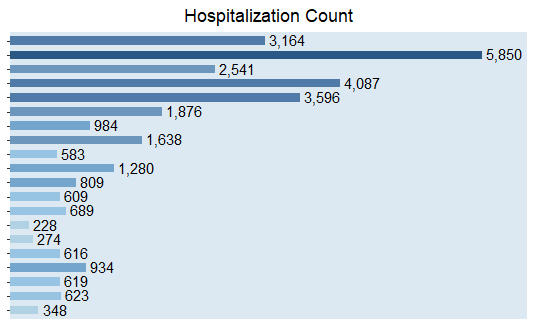

```r
hosp_bar
```

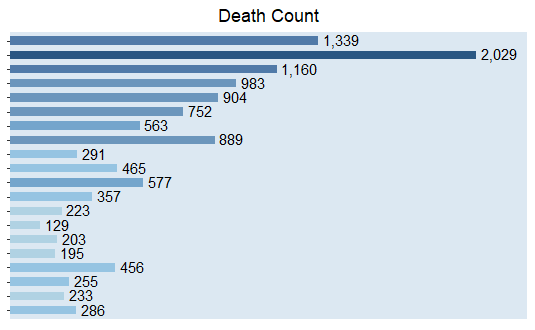

```r
deaths_bar
```